# Análise de Saúde

Caroline de Oliveira e Matheus Monteiro Alves Melo

12/06/2025

## 1. Introdução

Os dados utilizados foram obtidos no Painel Saúde, uma plataforma que reúne informações públicas sobre óbitos e internações, organizadas a partir do DataSUS (Ministério da Saúde), com base nas classificações internacionais de doenças (CID) relacionadas ao uso de álcool e outras drogas. As bases analisadas estão disponíveis no seguinte [site oficial](https://www.gov.br/mj/pt-br/assuntos/sua-protecao/politicas-sobre-drogas/obid/saude).

Os dados contemplam o período de 2000 a 2022, mas neste relatório as análises foram limitadas aos anos de 2013 a 2022. As bases analisadas são segmentadas em quatro categorias: Mortalidade por Álcool, Mortalidade por Outras Drogas, Internações por Álcool e Internações por Outras Drogas. Além disso, foi utilizada uma base de dados populacional dos municípios do Espírito Santo, retirada da Pesquisa Nacional por Amostra de Domicílios (PNAD).

As variáveis utilizadas no relatório incluem o ano de ocorrência, o número de óbitos e internações por município e estado, além da população estimada para os respectivos locais. Para fins de clareza e legibilidade, os nomes técnicos dos códigos das variáveis não foram apresentados neste relatório.

É importante ressaltar que o Projeto Estado Presente é aplicado a bairros específicos dentro dos municípios, e não ao município como um todo. Portanto, as análises apresentadas podem estar mascaradas, uma vez que agregam dados de áreas não contempladas pelo programa. Por exemplo, considerar todo o município de Vitória na análise pode diluir os efeitos observados nos bairros-alvo, como Nova Palestina. Abaixo, apresentamos a lista dos bairros atendidos pelo programa:

- Nova Palestina, Bairro da Penha e Piedade (Vitória);
- Barramares, Ulisses Guimarães, Boa Vista (I e II), São Torquato e Santa Rita (Vila Velha);
- Feu Rosa, Vila Nova de Colares, Jardim Carapina, Novo Horizonte, Planalto Serrano, Central Carapina e Bairro das Laranjeiras (Serra);
- Castelo Branco, Nova Rosa da Penha, Flexal II e Nova Esperança (Cariacica);
- Adalberto S. Nader e Kubitschek (Guarapari);
- Zumbi e Village da Luz (Cachoeiro de Itapemirim);
- Jacupemba (Aracruz);
- Ayrton Senna e Bela Vista (Colatina);
- Interlagos e Aviso (Linhares);
- Vila Nova e Bom Sucesso (São Mateus).

Este relatório está organizado da seguinte forma:

- Seção 1: Foram apresentados os dados utilizados e o contexto metodológico;
- Seção 2: Dedicado à análise de indicadores, que tem o objetivo de apresentar a influência das ocorrências no estado;
- Seção 3: Realisada uma análise com dados absolutos, para se obter a dimensão do que ocorre.
- seção 4: Foi realizada um análise com taxas de ocorrência, com as mesmas partições da seção 3;
- Seção 5: Análise com foco em taxas dos municípios do Projeto Estado Presente;
- Seção 6: Análises de tendência e autocorreçlação com o uso de testes;
- Seção 7: Análise da Qualidade dos dados;
- Seção 8: Análises espaciais de autocorrelação, com foco no índice de Moran;
- Seção 9: Considerações finais e implicações para políticas públicas.

### 1.1 Espírito Santo e municípios

Ao longo deste relatório, está presente diversas comparações entre grupos de municípios e o estado. Para melhor compreensão, é preciso conhecer o estado do Espírito Santo (Mapa 1).

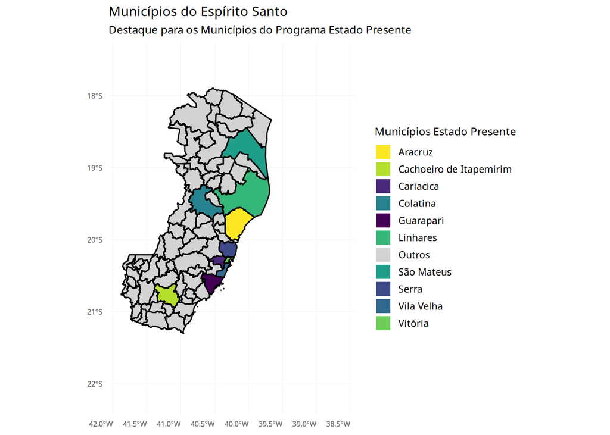

Mapa 1: ES e municípios do estado presente

O Espírito Santo é dividido em 78 municípios, com uma população ao longo dos anos representada por:

Tabela 1: População por Região e Ano

| Ano | Espírito Santo (ES) | Estado Presente (EP) | Demais Regiões |
| --- | --- | --- | --- |
| 2013 | 3839366 | 2462318 | 1377048 |
| 2014 | 3885049 | 2496594 | 1388455 |
| 2015 | 3929911 | 2530258 | 1399653 |
| 2016 | 3973697 | 2563052 | 1410645 |
| 2017 | 4016356 | 2594744 | 1421612 |
| 2018 | 3972388 | 2580773 | 1391615 |
| 2019 | 4018650 | 2616446 | 1402204 |
| 2020 | 4064052 | 2651458 | 1412594 |
| 2021 | 4108508 | 2685734 | 1422774 |
| 2022 | 3833712 | 2480513 | 1353199 |

Tendo como Municípios mais populosos ao longo dos anos:

Tabela 2: Top 5 Municípios Mais Populosos por Ano

| 2013 | 2014 | 2015 | 2016 | 2017 | 2018 | 2019 | 2020 | 2021 | 2022 |
| --- | --- | --- | --- | --- | --- | --- | --- | --- | --- |
| Vila Velha | Vila Velha | Serra | Serra | Serra | Vila Velha | Serra | Vila Velha | Vila Velha | Serra |
| Vitória | Serra | Vila Velha | Vila Velha | Vila Velha | Serra | Vila Velha | Cariacica | Serra | Vila Velha |
| Cariacica | Vitória | Cariacica | Vitória | Vitória | Vitória | Cariacica | Vitória | Vitória | Vitória |
| Serra | Cariacica | Vitória | Cariacica | Cachoeiro de Itapemirim | Cariacica | Vitória | Serra | Cariacica | Linhares |
| Cachoeiro de Itapemirim | Cachoeiro de Itapemirim | Cachoeiro de Itapemirim | Cachoeiro de Itapemirim | Cariacica | Cachoeiro de Itapemirim | Cachoeiro de Itapemirim | Cachoeiro de Itapemirim | Cachoeiro de Itapemirim | Cariacica |

é interessante pontuar que os municípios mais populosos são também municípios participantes do Projeto, o que pode justificar o maior número de ocorrências no local, como será observado ao longo do relatório.

## 2. Análise de indicadores

Indicadores são resumos de grandes quantidades de informações, usados para resumir e facilitar a descrição e interpretação dos dados, são usados para comparar a tendência de diferentes grupos, o comportamento dos dados ao longo do tempo e o quanto uma informação impacta em outra. Nesse relatório foram criados 4 indicadores, sendo eles:

- Número de internações decorrentes do consumo de álcool nos municípios do Projeto Estado Presente a cada 100 internações decorrentes do consumo de álcool no estado;
- Número de internações decorrentes do uso de outras drogas nos municípios do Projeto Estado Presente a cada 100 internações decorrentes do uso de outras drogas no estado;
- Número de óbitos decorrentes do consumo de álcool nos municípios do Projeto Estado Presente a cada 100 óbitos decorrentes do consumo de álcool no Estado;
- Número de óbitos decorrentes do uso de outras drogas nos municípios do Projeto Estado Presente a cada 100 óbitos decorrentes do uso de outras drogas no Estado;

### 2.1 Indicadores de internações (por álcool e outras drogas)

Os indicadores apresentados nesta seção foram criados dividindo o número de ocorrências de cada ano nos municípios participantes no projeto pelo número total de ocorrências, por ano, no estado. Ele apresenta a influência que as mortes nos municípios contemplados no projeto têm nas mortes do estado.

Indicador 1:

$$I_1 = \frac{\text{Nº de Internações Decorrentes do Consumo de Álcool nos
Municípios do Estado Presente}}{\text{Nº de Internações Decorrentes do
Consumo de Álcool no Espírito Santo}} \cdot 100$$
Indicador 2:

$$I_2 = \frac{\text{Nº de Internações Decorrentes do Uso de Outras Drogas
nos Municípios do Estado Presente}}{\text{Nº de Internações Decorrentes
do Uso de Outras Drogas no Espírito Santo}} \cdot 100$$

[interactive chart not shown]

A partir do Gráfico 1, é possível perceber que em 2013, as internações causadas pelo uso de outras drogas representavam 99,64% das internações do estado (a cada 100 mortes no Espírito Santo, 99 delas foram em municípios contemplados pelo Projeto Estado Presente). E ao longo do tempo essa representação diminuiu, com seu menor percentual em 2021, quando as internações por drogas representam 61% das internações do estado.

Assim como a internação por outras drogas, a internação por Álcool segue um comportamento similar. Começando em 2013 representando 89,40% das internações desta categoria no estado e finalizando em 2022 com 37,71%, tendo uma redução maior que a do indicador para outras drogas.

Interessante notar que para ambos os indicadores, a redução entre 2017 - 2022 (35,25% e 25,36% respectivamente) é superior a redução entre 2013 e 2017 (16,44% e 8,26%, respectivamente), além da COVID, outro evento presente nesse período foi o Projeto Estado Presente.

### 2.2 Indicadores de mortalidade (por álcool e outras drogas)

Indicador 3:

$$I_3 = \frac{\text{Nº de Óbitos Decorrentes do Consumo de Álcool nos
Municípios do Estado Presente}}{\text{Nº de Óbitos Decorrentes do
Consumo de Álcool no Espírito Santo}} \cdot 100$$
Indicador 4:

$$I_4 = \frac{\text{Nº de Óbitos Decorrentes do Uso de Outras Drogas nos
Municípios do Estado Presente}}{\text{Nº de Óbitos Decorrentes do Uso de
Outras Drogas no Espírito Santo}} \cdot 100$$

[interactive chart not shown]

Diferente dos indicadores para internações, os indicadores relativos à morte apresentam comportamentos não similares. Tem-se, analisando o Gráfico 2, que o indicador 3, referente às mortes pelo consumo de álcool, não sofreu grandes alterações ao longo dos anos, apresentando uma redução de 3,04% ao longo dos 10 anos analisados. O indicador 4, de óbitos pelo uso de outras drogas, apresenta índices menos homogêneos, tendo uma grande redução em 2017, chegando a representar 40% das mortes no estado após em 2013 ter representado 100% das mortes, ou seja, todas as mortes causadas pelo uso de drogas no estado foram mortes ocorridas nos municípios contempladas no projeto. Porém, esse comportamento de queda não se manteve, e após 2017 o índice sofreu aumento chegando a representar 94,74% das mortes do estado em 2019.

## 3. Análise com valores absolutos

### 3.1 Gráficos acerca de internações (por álcool e outras drogas)

## Gráficos de Internações

[interactive chart not shown]

Os Gráficos 3 e 4 foram produzidos com o valor total de internações em cada local e ano. Nota-se que a série referente aos municípios do Estado Presente apresenta comportamento similar ao da série do Espírito Santo em ambos os gráficos, e pode significar que as ocorrências no estado ocorreram em sua maioria, nos municípios contemplados pelo projeto. É notável também um decaimento acentuado no número de casos no estado entre os anos de 2014 e 2015, tendo seus menores valores em 2016 (263 internações pelo uso de drogas e 2020(821 internações pelo consumo de álcool).

Para internações causadas pelo consumo de álcool o Gráfico 3 mostra que houve, nos municípios do Estado Presente, 1814 internações em 2013 e 362 em 2022, tendo seu menor número de ocorrências neste ano. Já o Gráfico 4, de internações por outras drogas, é apresentado um comportamento com maiores oscilações, tendo diminuído drasticamente o número de internações até 2016 e aumentado entre 2016 e 2018. Acerca das internações nos municípios que não fazem parte do Projeto, é visível um comportamento oposto dos demais, ao longo desses 10 anos, o número de internações aumentou nesse grupo, enquanto reduziu nos demais.

### 3.2 Gráficos acerca de óbitos (por álcool e outras drogas)

## Gráficos de Óbitos

[interactive chart not shown]

Assim como nos Gráficos 3 e 4, os Gráficos de óbitos 5 e 6 também demonstram similaridade entre ocorrências no estado inteiro e apenas nos municípios do projeto Estado Presente. É possível observar uma oscilação maior do número de óbitos pelo uso de outras drogas no estado e no Estado Presente, no ano de 2021 ( 32 mortes do estado e 25 no Estado Presente), enquanto no restante dos anos, esse número não ultrapassa 19. Já para as informações do restante dos municípios, diferente do número de internações por álcool, o número de mortes pelo consumo de álcool não apresentou uma grande alteração entre os 10 anos (aumento de 2 mortes) 78 em 2022. A cerca dos óbitos pelo uso de drogas, o Gráfico 6 sugere maiores oscilações nas ocorrências, assim como no restante dos recortes.

## 4. Taxa de ocorrências pelas populações referentes

Os gráficos de taxa apresentados nessa seção foram desenvolvidos pela razão entre o número de mortes do local de interesse e o número da população do respectivo local, multiplicando o resultado por 100 000 para melhor visualização. Portanto, cada valor no gráfico, representa o número de ocorrências a cada 100 000 habitantes (população) naquele ano.

### 4.1 Internações

## Gráficos da Taxa de Internações

[interactive chart not shown]

O Gráfico 8 de internação por uso de drogas apresenta um comportamento interessante, onde assim como no Gráfico 7, a taxa no estado e no Estado Presente diminuíram, enquanto a taxa nos municípios não contemplados aumentou, porém diferente do Gráfico de álcool, os valores se aproximam durante os anos de 2020, 2021 e 2022, anos em que se ocorria a pandemia da COVID no Brasil.

### 4.2 Óbitos

## Gráficos da Taxa de Óbitos

[interactive chart not shown]

Diferente dos Gráficos de taxa 7 e 8, nos Gráficos 9 e 10, as taxas não apresentaram nenhum comportamento extremo. No Gráfico 9, é possível notar que os três locais apresentaram comportamentos similares, com os municípios do Estado Presente apresentando maiores taxas, enquanto os municípios não pertencentes apresentaram menores taxas.

No Gráfico 10, é possível notar que em relação aos outros gráficos, as taxas de óbitos pelo uso de outras drogas são mais baixas, podendo indicar uma menor quantidade de ocorrências ou até a falta de dados na base estudada.

## 5. Análise com foque nos municípios do projeto

## Taxa de Internação nos Municípios

[interactive chart not shown]

Nessa seção é dado um foco maior para os municípios do projeto, especificamente acerca das internações nesses municípios. As taxas foram geradas seguindo a mesma fórmula informada na seção 4 do relatório.  
No Gráfico 11, observa-se uma taxa elevada nos anos de 2013 e 2014 no município de Cachoeiro de Itapemirim, não só em comparação com os outros municípios, mas com ele mesmo nos anos subsequentes. Sugere-se uma investigação para compreender as razões que levaram a tais quantidades. Outro município com taxas mais elevadas em comparação aos outros é Vitória, que também possui altas taxas quando comparadas aos demais municípios que participam do estudo.

Sobre o Gráfico 12, é possível observar que Cachoeiro de Itapemirim também apresenta taxas elevadas para internações por uso de outras drogas nos anos 2013 e 2014 e nota-se também que Vitória continua com números mais altos que os demais, porém, agora é visível que Cariacica também apresenta números um pouco mais elevados entre 2018 e 2021, anos de vigência do Projeto.

Um ponto interessante é o fato de que Guarapari está com a taxa de internações em 0 para ambos os motivos, o que, se tratando de um município grande (como visto no mapa 1) pode ser estranho, podendo significar precariedade da base utilizada ou um comportamento isolado que deve ser estudado.

## 6. Análise de tendência

Além das análises descritivas realizadas ao longo do relatório, foram analisadas também séries temporais de internações e óbitos causados pelo consumo de álcool e uso de outras drogas nos municípios participantes do Projeto Estado Presente, considerando o período de 2013 a 2022. A análise foi conduzida por meio de testes de tendência (Mann-Kendall) e de autocorrelação (Ljung-Box), avaliando tanto os valores absolutos quanto as taxas padronizadas por população.

Em relação às internações por álcool nos municípios do Projeto, não foram observadas evidências estatísticas de tendência significativa de crescimento ou decréscimo nos números absolutos, tampouco nas taxas relativas à população. Já as internações por outras drogas apresentaram indícios estatísticos de redução nos números absolutos ao longo dos anos analisados ($p<0{,}05$), embora tal tendência não tenha se mantido nas taxas padronizadas por população. Esses achados sugerem que, no âmbito das internações, os efeitos do Projeto Estado Presente parecem ter sido mais relevantes no enfrentamento das consequências relacionadas às outras drogas do que ao álcool.

Quanto aos óbitos causados pelo uso de substâncias psicoativas, os resultados também apontam diferenças conforme o tipo de substância. No caso do álcool, tanto os números absolutos quanto as taxas de mortalidade não apresentaram tendência significativa de crescimento ou decréscimo após a implementação do programa. No entanto, para as mortes associadas ao uso de outras drogas, verificou-se uma tendência de queda estatisticamente significativa antes da implantação do Estado Presente ($p<0{,}05$), a qual não se manteve no período posterior. Apesar disso, a análise das taxas de mortalidade por outras drogas indicou um gradual decréscimo ao longo dos anos após a implantação do programa, sugerindo um possível efeito positivo na contenção da mortalidade por esse tipo de causa.

A análise desagregada por município revelou que apenas Vitória apresentou tendência significativa de redução nas taxas de internação por álcool após a implantação do programa. Para os demais municípios participantes, não foram observadas tendências estatísticas claras de crescimento ou queda nas internações relacionadas ao álcool ou às outras drogas. Um caso particular foi o de Cachoeiro de Itapemirim, município pertencente ao Estado Presente, onde se observou uma expressiva tendência de redução nas internações por álcool e outras drogas no período anterior à implementação do Projeto, sem alterações relevantes posteriormente.

De forma geral, os resultados sugerem que o Programa Estado Presente pode ter contribuído de maneira mais consistente para a redução da mortalidade relacionada ao uso de outras drogas do que para a redução das internações hospitalares associadas ao consumo de substâncias psicoativas. Esses achados apontam para a importância de políticas públicas de segurança e saúde que considerem as especificidades regionais e o tipo de substância envolvida, além de reforçarem a necessidade de avaliações contínuas de impacto a fim de aprimorar as estratégias adotadas.

## 7. Qualidade dos Dados

### 7.1 Outras Drogas

A análise dos dados de internações e óbitos associados ao uso de outras drogas revelou uma distribuição bastante desigual entre os municípios capixabas nos anos de 2017 e 2022. Observou-se uma significativa ausência de registros em diversos municípios, especialmente no ano de 2022. Esse padrão pode refletir uma possível redução nos eventos, ou até estar associado à subnotificação ou à interrupção nos fluxos de informação durante a pandemia de COVID-19.

O contexto pandêmico pode ter impactado negativamente tanto o acesso aos serviços de saúde quanto os mecanismos de registro e codificação dos atendimentos hospitalares e causas de morte. Com isso, diversos municípios — especialmente os de menor porte — deixaram de apresentar registros consistentes, o que prejudica a análise de tendência temporal, resultando em séries históricas truncadas ou descontinuadas. Além disso, essa lacuna informacional compromete a robustez das análises de autocorrelação espacial, como o Índice de Moran Local, pois a ausência de dados pode induzir à falsa percepção de concentração ou dispersão dos eventos.

Dessa forma, os resultados relativos às outras drogas devem ser interpretados com cautela. As limitações estruturais dos sistemas de informação em determinados territórios, agravadas pela pandemia, impõem barreiras à interpretação confiável de padrões espaciais e temporais. Estudos futuros poderão se beneficiar de métodos de imputação de dados ou modelagens que incorporem incertezas, de modo a melhor lidar com áreas de baixa cobertura informacional.

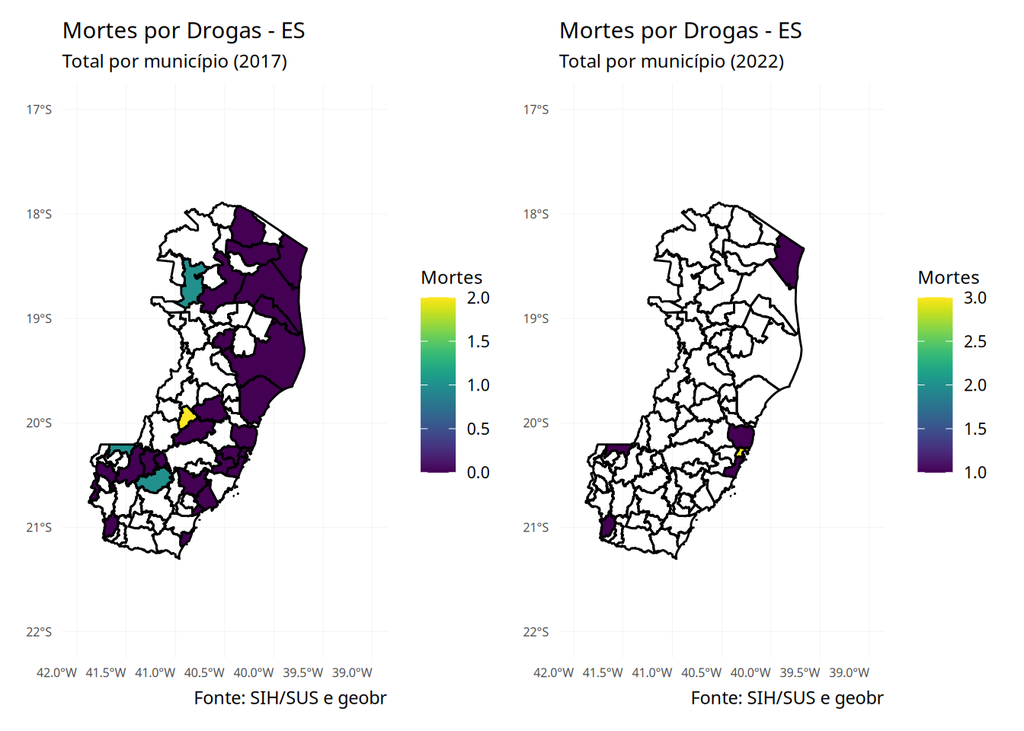

Mapa 2: Óbitos por outras drogas em 2017 e 2022

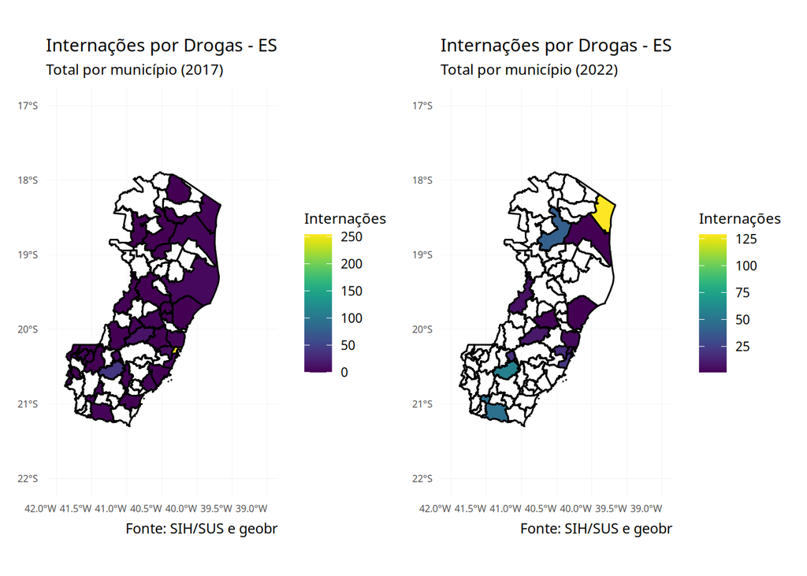

Mapa 3: Internação por outras drogas em 2017 e 2022

### 7.2 Álcool

Em contraste com os dados de outras drogas, os mapas referentes às internações e óbitos relacionados ao uso de álcool apresentaram maior consistência e continuidade nos registros ao longo dos anos analisados. Essa maior estabilidade nos dados sugere que os sistemas de registro para causas associadas ao álcool foram menos afetados pelas consequências provocadas pela pandemia, permitindo inferências mais confiáveis tanto sobre padrões espaciais quanto sobre tendências ao longo do tempo.

A presença mais ampla e uniforme de registros nos diferentes municípios permite uma avaliação territorial mais robusta do impacto do Programa Estado Presente. Os dados de 2017 — ano anterior ao início do programa — e de 2022 — ano subsequente ao auge da pandemia — oferecem uma base mais adequada para verificar variações na carga de internações e óbitos relacionados ao álcool, inclusive permitindo análises com métodos mais sensíveis a variações locais, como os indicadores de autocorrelação espacial e testes de tendência temporal.

Esse contraste entre álcool e outras drogas reforça a importância de avaliar criticamente a qualidade e a cobertura dos dados antes de realizar inferências sobre o impacto de políticas públicas. Enquanto os dados de álcool se mostraram mais confiáveis para análises territoriais, os de outras drogas exigem abordagens metodológicas mais cuidadosas para que não se atribuam padrões espúrios a políticas públicas ou a eventos contextuais como a pandemia.

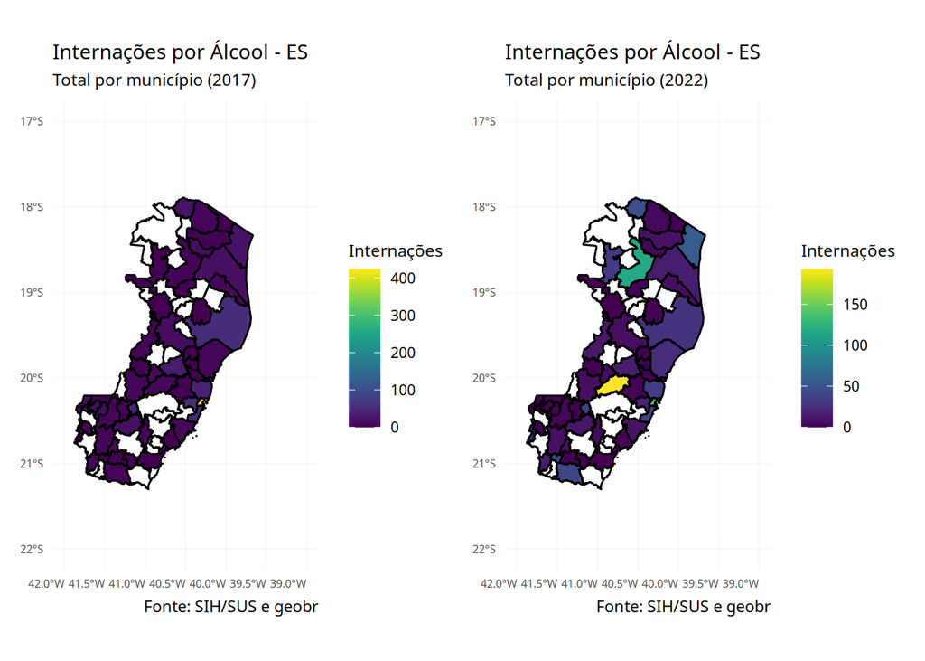

Mapa 4: Internação por álcool em 2017 e 2022

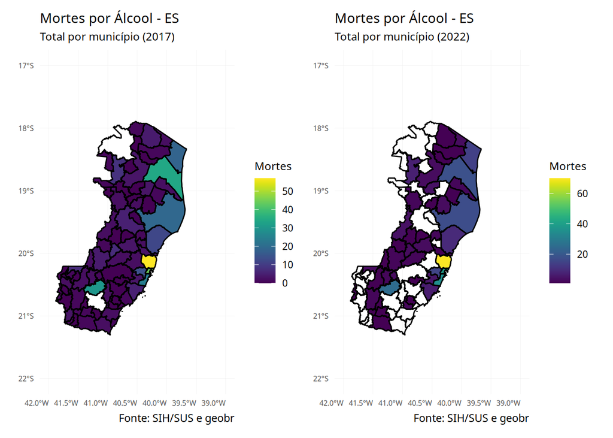

Mapa 5: Óbitos por álcool em 2017 e 2022

## 8. Análise de Correlação Espacial

Para investigar padrões espaciais relacionados às internações e óbitos por álcool e outras drogas, foram realizadas análises de autocorrelação espacial utilizando o Índice de Moran Local (LISA). Esse índice permite identificar agrupamentos espaciais (clusters) e avaliar a dependência espacial entre os municípios, ou seja, se áreas geograficamente próximas tendem a apresentar valores semelhantes. Previamente à aplicação do LISA, foram calculados os totais de óbitos por álcool, óbitos por outras drogas, bem como as internações por essas causas para cada município do Espírito Santo, a fim de consolidar as variáveis de interesse.

De forma geral, nos demais municípios analisados não foram observadas correlações espaciais estatisticamente significativas, tanto para internações por álcool e outras drogas quanto para os óbitos relacionados. Esses resultados indicam uma ausência de padrões de autocorrelação espacial localmente consistentes, o que pode estar relacionado à variabilidade territorial de fatores sociais, econômicos e estruturais que influenciam esses desfechos.

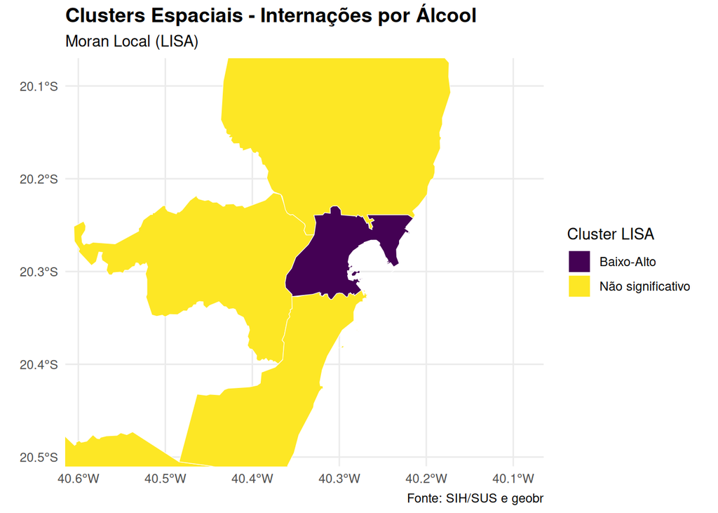

Mapa 6: Análise espacial para internações por álcool

## 9. Conclusões

A comparação temporal entre 2017 e 2022 mostrou aumento nas internações em municípios como Linhares e São Mateus, e redução em Vitória e Vila Velha, sugerindo impactos territoriais diferenciados do programa. Contudo, destaca-se uma limitação relevante: as análises foram feitas em escala municipal, enquanto o programa atua em bairros específicos. Isso pode ter mascarado variações importantes dentro dos municípios, especialmente em áreas de alta vulnerabilidade social. Além disso, os efeitos da pandemia de COVID-19 também podem ter influenciado os dados de internações e mortalidade, especialmente nos anos de 2020 e 2021. Recomenda-se que estudos futuros adotem uma escala mais detalhada (como bairros ou setores censitários) e incorporem variáveis socioeconômicas e de acesso à saúde, a fim de orientar políticas públicas mais precisas e eficazes.